# Chinese Foreign Investment and ‘One Belt, One Road’

Cian Stryker

11/25/2019

There is a consensus among experts that with the dissolution of the USSR in 1991, the world became unipolar with the United States enjoying a near total global hegemony in both political and economic terms. The explosive economic growth of China, however, from the early 2000’s to now, has challenged this concept and shifted public opinion to recognize the advent of a multi-polar world. A major goal of China during this period has been domestic economic growth, but as its economy improved drastically, so did China’s investment in foreign countries. Considering the Chinese Government’s economic model, the relationship between private firms and the Communist party is closer than in most other countries. Examining China’s Foreign Direct Investment, therefore gives insight into the Chinese government’s overall geopolitical goals. This is especially true with the announcement of the ‘One Belt, One Road project’ in 2014, where President Xi made it clear that China was interested in recreating the Ancient Silk road by investing in infrastructural projects across the world that lead to China. This ambitious infrastructural investing project is mostly targeted towards developing regions such as West Asia, the Middle East, Sub-Saharan Africa, and South America. Many experts believe that this initiative, the Belt and Road Initiative, is actually an ambitious attempt to win political influence and capture emerging markets in vital areas neglected by the U.S. with the ultimate goal of shifting the economic center of the world from New York City to Beijing.

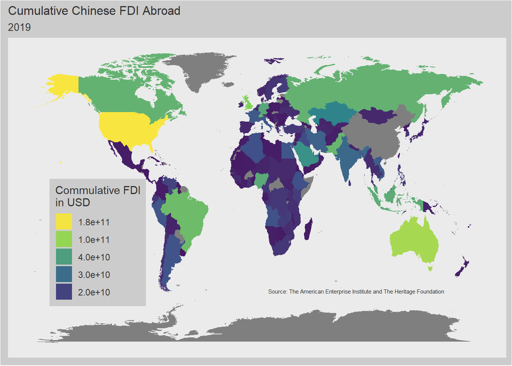

The American Enterprise Institute and Heritage Foundation has recorded almost every single Chinese Foreign Direct Investment since 2005 to now. The cumulative amounts of this investment can be seen in the world map above. The important note here is to see that China has invested in almost every single country in the world, but a truly massive amount in the U.S. and other key countries.

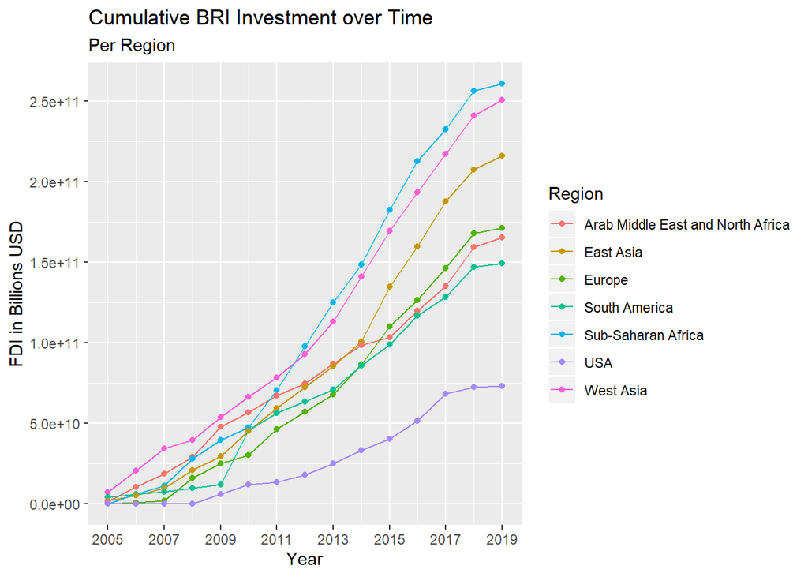

Measuring the real effects of the Belt and Road Initiative is a daunting task and academic attempts to do so have not been entirely successful. Measuring the factors that cause China to invest in particular countries is potentially easier. That being said, this is not an academic piece and so I am avoiding stringent and nuanced models that attempt to identify a causal variable. This is an introductory report whose goal is largely descriptive in nature. Therefore, my model is much simpler than an academic model would be. I use GDP PPP (Purchasing Power Parity) from the World Bank to illustrate what relationship, if any, exists between Chinese BRI investment and overall economic health. My attempt to do this begins with a scatter plot that has a linear regression line written in for a visualization of the relationship. As you can see below, the two have a positive relationship as demonstrated by the upward slope of the regression line. You can also see, however, that many countries fall outside of the standard errors, which demonstrates that this relationship is not capturing all the variance that exists.

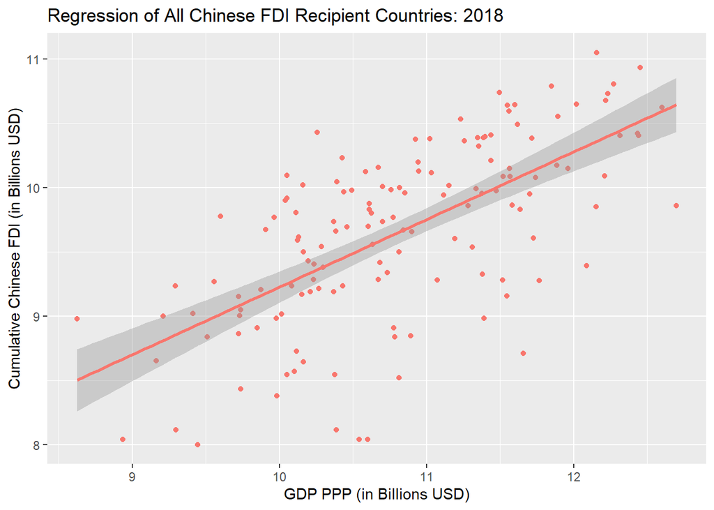

The purpose of this report was not to identify any causal impact of Chinese foreign direct investment or the Belt and Road Initiative overall. That is task that requires much more precise models and more data than is realistically available at this point. The purpose was to describe in broad terms the scope of Chinese FDI and if any general economic or political trends are visible due to this large-scale investment initiative. China’s economic growth has been shocking and its growing role in the international community as a leading figure dictates that its activities should be better understood and analyzed. This report will hopefully serve as a useful introduction to this topic.